# Project1DataExploration

Team 1: Khalid Abdulshafi, Cecilia Chen, Micah Duwell, Reed Herndon, Grant Sobczak

1/30/2022

# Data Import and Cleaning

```r
  # Initial load-in of the data and observations.
  lng <- read.csv("ProjectA_Listings2013.csv")
  str(lng)
```

```
## 'data.frame':    33542 obs. of  51 variables:
##  $ number_of_days               : int  1095 1095 1095 296 1095 1095 1095 1095 1095 1095 ...
##  $ principal_balance            : num  969 0 0 3636 0 ...
##  $ loan_status                  : int  1 3 4 2 4 4 1 4 4 4 ...
##  $ loan_status_description      : chr  "CURRENT" "DEFAULTED" "COMPLETED" "CHARGEOFF" ...
##  $ loan_origination_date        : chr  "1/3/2013" "1/3/2013" "1/3/2013" "1/3/2013" ...
##  $ amount_funded                : num  2000 2000 2000 4000 5500 10000 6500 3000 4000 2200 ...
##  $ prosper_rating               : chr  "B" "D" "E" "HR" ...
##  $ borrower_rate                : num  16.9 24.2 27.9 31.3 12.5 ...
##  $ listing_term                 : int  60 36 36 36 36 36 36 36 60 60 ...
##  $ listing_monthly_payment      : num  49.6 78.7 82.6 172.8 184 ...
##  $ scorex                       : chr  "702-723" "650-664" "620-639" "640-649" ...
##  $ prosper_score                : int  7 4 3 7 7 7 5 3 3 6 ...
##  $ listing_category_id          : int  13 13 1 2 1 1 1 1 1 1 ...
##  $ income_range                 : int  4 6 2 2 4 3 6 5 4 4 ...
```

[output cut: 37 more lines]

```r
  summary(lng)
```

```
##  number_of_days   principal_balance  loan_status    loan_status_description
##  Min.   :  94.0   Min.   :    0.0   Min.   :1.000   Length:33542
##  1st Qu.: 816.0   1st Qu.:    0.0   1st Qu.:1.000   Class :character
##  Median : 879.0   Median :  903.8   Median :2.000   Mode  :character
##  Mean   : 879.3   Mean   : 3004.2   Mean   :2.406
##  3rd Qu.: 974.0   3rd Qu.: 4872.1   3rd Qu.:4.000
##  Max.   :1095.0   Max.   :32998.2   Max.   :4.000
##
##  loan_origination_date amount_funded   prosper_rating     borrower_rate
##  Length:33542          Min.   : 2000   Length:33542       Min.   : 5.65
##  Class :character      1st Qu.: 4000   Class :character   1st Qu.:13.59
##  Mode  :character      Median :10000   Mode  :character   Median :17.69
##                        Mean   :10551                      Mean   :18.34
##                        3rd Qu.:15000                      3rd Qu.:22.72
##                        Max.   :35000                      Max.   :31.65
##
##   listing_term   listing_monthly_payment    scorex          prosper_score
##  Min.   :12.00   Min.   :  41.22         Length:33542       Min.   : 1.000
##  1st Qu.:36.00   1st Qu.: 165.15         Class :character   1st Qu.: 4.000
##  Median :36.00   Median : 295.81         Mode  :character   Median : 5.000
##  Mean   :45.19   Mean   : 325.38                            Mean   : 5.478
##  3rd Qu.:60.00   3rd Qu.: 419.94                            3rd Qu.: 7.000
##  Max.   :60.00   Max.   :2251.51                            Max.   :11.000
##
##  listing_category_id  income_range   income_range_description
##  Min.   : 0.00       Min.   :1.000   Length:33542
##  1st Qu.: 1.00       1st Qu.:3.000   Class :character
##  Median : 1.00       Median :4.000   Mode  :character
##  Mean   : 2.83       Mean   :4.241
##  3rd Qu.: 2.00       3rd Qu.:5.000
##  Max.   :20.00       Max.   :7.000
##
##  stated_monthly_income income_verifiable dti_wprosper_loan
##  Min.   :     0        Mode :logical     Min.   :      0.0
##  1st Qu.:  3750        FALSE:2143        1st Qu.:      0.2
##  Median :  5250        TRUE :31399       Median :      0.2
##  Mean   :  6162                          Mean   :  62489.1
##  3rd Qu.:  7458                          3rd Qu.:      0.3
##  Max.   :618548                          Max.   :1000000.0
##
```

[output cut: 73 more lines]

```
##  Min.   : 0.000       Min.   : 0.000            Min.   : 0.000
##  1st Qu.: 0.000       1st Qu.: 0.000            1st Qu.: 0.000
##  Median : 1.000       Median : 1.000            Median : 0.000
##  Mean   : 2.185       Mean   : 3.361            Mean   : 1.649
##  3rd Qu.: 3.000       3rd Qu.: 4.000            3rd Qu.: 2.000
##  Max.   :37.000       Max.   :99.000            Max.   :79.000
##
##  delinquencies_over90_days is_homeowner
##  Min.   : 0.000            Mode :logical
##  1st Qu.: 0.000            FALSE:15448
##  Median : 0.000            TRUE :18094
##  Mean   : 3.823
##  3rd Qu.: 2.000
##  Max.   :99.000
##
```

```r
  # Data cleaning
  lng$loan_status <- as.factor(lng$loan_status)

  lng$prosper_rating <- as.factor(lng$prosper_rating)

  # Make it easier to access by date
  lng$loan_origination_date <- as.factor(lng$loan_origination_date)
# define original format of date
initial_format<-strptime(lng$loan_origination_date,format="%m/%d/%Y")
# define desired format of date
lng$loan_origination_date<-as.Date(initial_format,format="%m/%d/%Y")

  lng$scorex <- as.factor(lng$scorex)
  lng$prosper_score <- as.factor(lng$prosper_score)
  lng$listing_category_id <- as.factor(lng$listing_category_id)
  lng$income_range <- as.factor(lng$income_range)

  lng$employment_status_description <- as.factor(lng$employment_status_description)
  lng$occupation <- as.factor(lng$occupation)
  lng$borrower_state <- as.factor(lng$borrower_state)
  lng$borrower_city <- as.factor(lng$borrower_city)
  lng$lender_indicator <- as.factor(lng$lender_indicator)
```

```r
 # Lender indicator: Segment by FALSE to get borrowers
  borrowers <- subset(lng, lng$lender_indicator == 0)
```

> In the original dataset, the majority of data is for borrowers. There is not much data for lenders to draw any solid conclusion. Therefore, in the following analysis, we will focus on the borrowers. There are 33542 total rows in this dataset, but only 31711 borrowers.

# Data Analysis

## Principal Balance

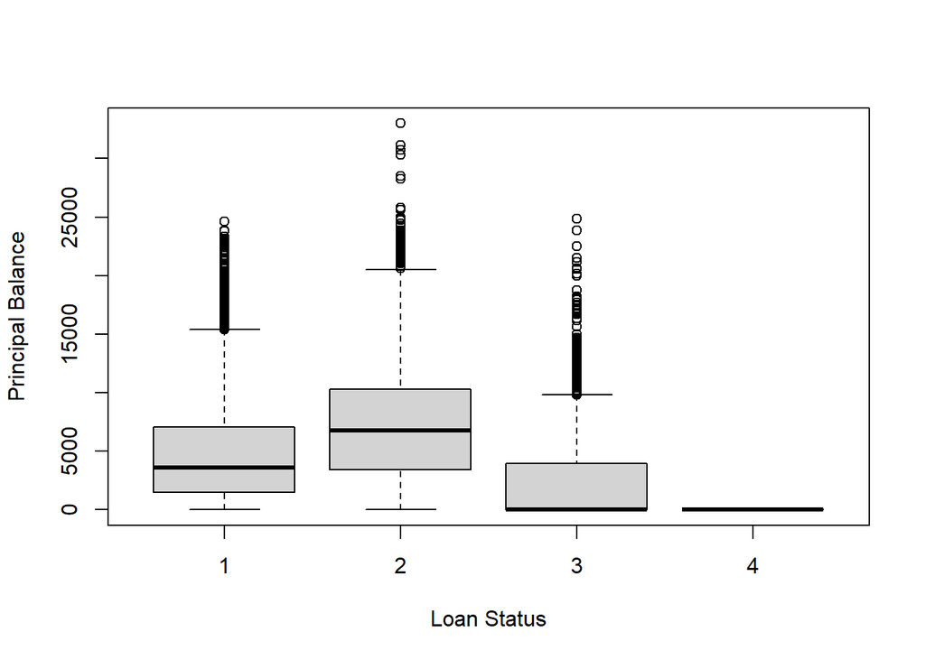

```r
plot(borrowers$loan_status, borrowers$principal_balance, xlab="Loan Status", ylab="Principal Balance")
```

> Debtors who charged off their loan had the highest principal balance.

## Loan Origination Date

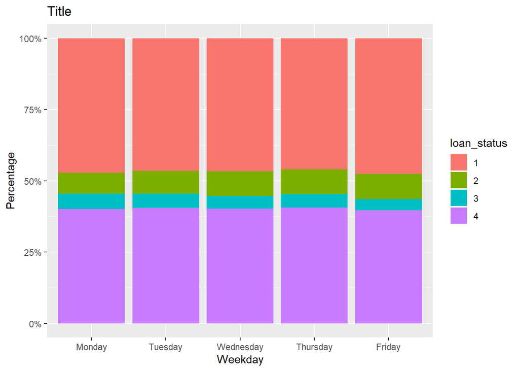

```r
category_weekday <- weekdays(borrowers$loan_origination_date)
weekday_order <- c("Monday", "Tuesday", "Wednesday", "Thursday", "Friday")
ggplot(data = borrowers, aes(x=factor(category_weekday, level = weekday_order), fill = loan_status)) + geom_bar(stat="count", position = "fill") + labs(title = "Title") + labs(x="Weekday", y = "Percentage")+ scale_y_continuous(labels = scales::percent)
```

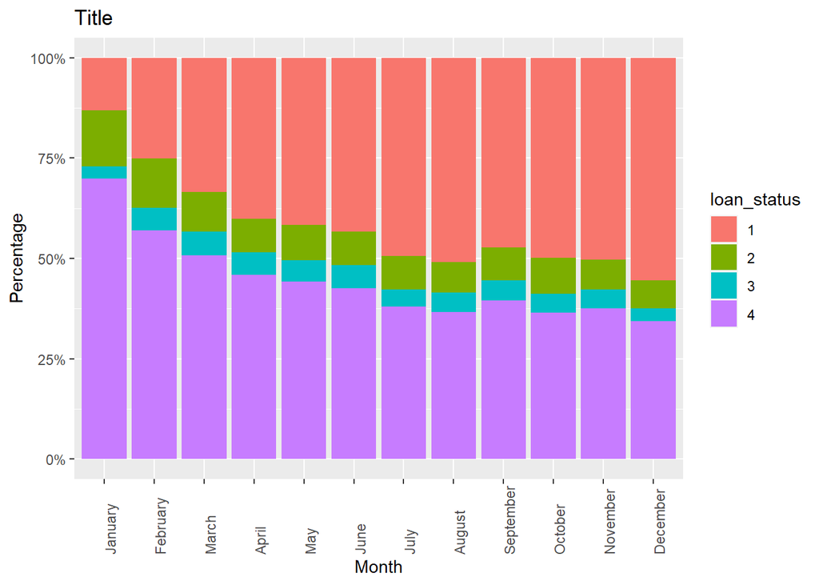

```r
category_month <- months(borrowers$loan_origination_date)
month_order <- c("January", "February", "March", "April", "May", "June", "July", "August", "September", "October", "November", "December")
ggplot(data = borrowers, aes(x=factor(category_month, level = month_order), fill = loan_status)) + geom_bar(stat="count", position = "fill") + labs(title = "Title") + labs(x="Month", y = "Percentage")+ scale_y_continuous(labels = scales::percent) + theme(axis.text.x = element_text(angle = 90,hjust =0 ))
```

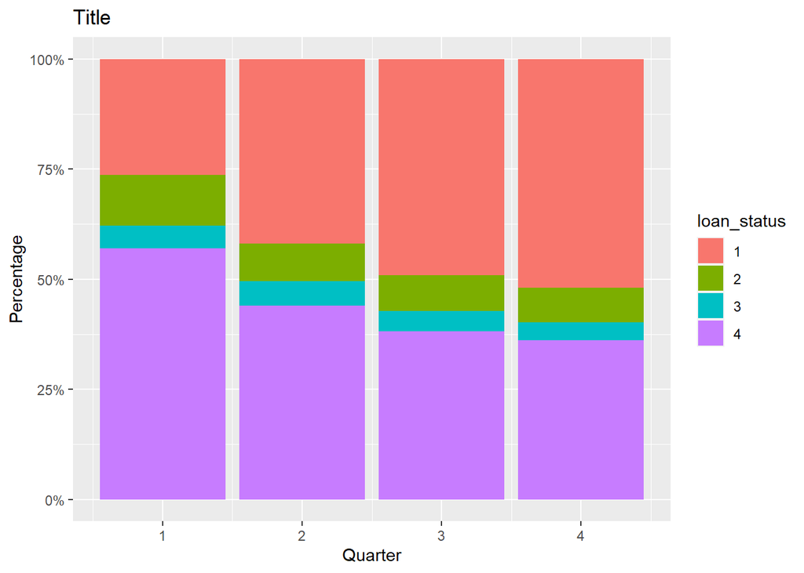

```r
category_quarter <- quarter(borrowers$loan_origination_date)
ggplot(data = borrowers, aes(x=category_quarter, fill = loan_status)) + geom_bar(stat = "count", position = "fill") + labs(title = "Title") + labs(x="Quarter", y = "Percentage")+ scale_y_continuous(labels = scales::percent)
```

> The day of the week made no difference in the amount of debtors charging off or defaulting on their loan.

> The first 6 months (i.e. the first two quarters) displayed the most debtors charging off or defaulting on their loan.

## Amount Funded

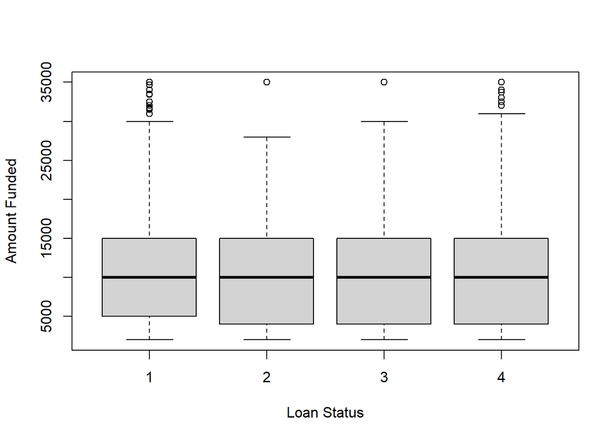

```r
plot(borrowers$loan_status, borrowers$amount_funded, xlab="Loan Status", ylab="Amount Funded")
```

> The amount funded to debtors made no difference in the amount of debtors charging off or defaulting on their loan.

## Prosper Rating

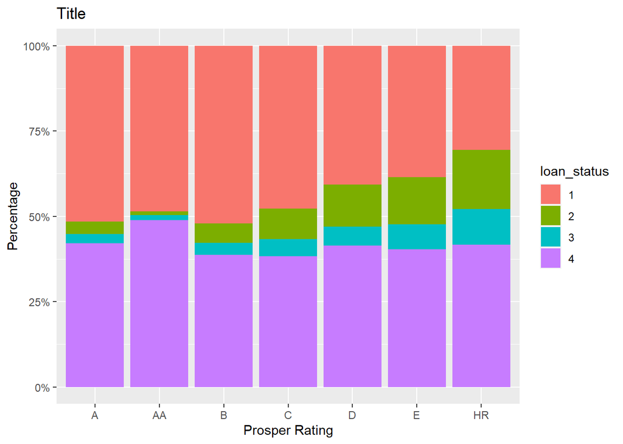

```r
ggplot(borrowers, aes(x=prosper_rating, fill = loan_status)) + geom_bar(stat = "count", position = "fill") + labs(title = "Title") + labs(x="Prosper Rating", y = "Percentage")+ scale_y_continuous(labels = scales::percent)
```

> The worse the Prosper rating, the more instances of debtors charging off or defaulting on their loan were observed.

## Interest Rate

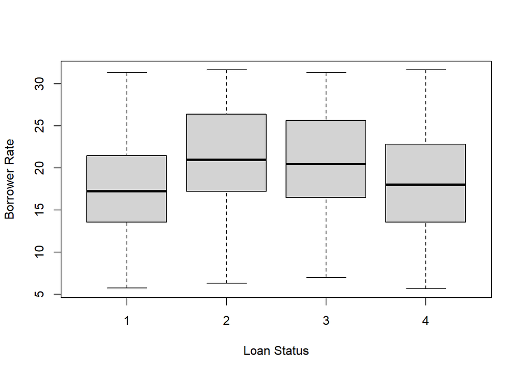

```r
plot(borrowers$loan_status, borrowers$borrower_rate, xlab="Loan Status", ylab="Borrower Rate")
```

> The debtors with higher interest rates charged off or defaulted on their loan more often than debtors who are either currently paying off their loan or have already paid off their loan.

## Loan Terms

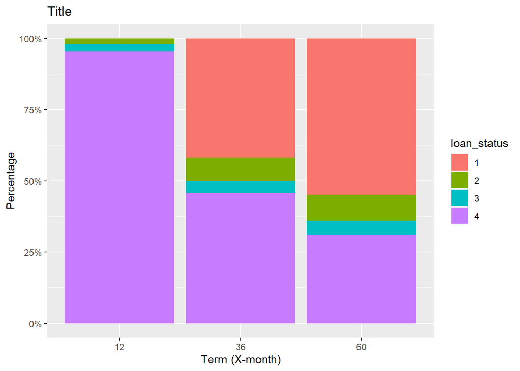

```r
# Factor listing term
borrowers$listing_term <- as.factor(borrowers$listing_term)
ggplot(borrowers, aes(x=listing_term, fill = loan_status)) + geom_bar(stat = "count", position = "fill") + labs(title = "Title") + labs(x="Term (X-month)", y = "Percentage")+ scale_y_continuous(labels = scales::percent)
```

> With a 12-term loan, debtors charged off or defaulted on their loan less than a 36-term or 60-month term loan.

## Monthly Payments

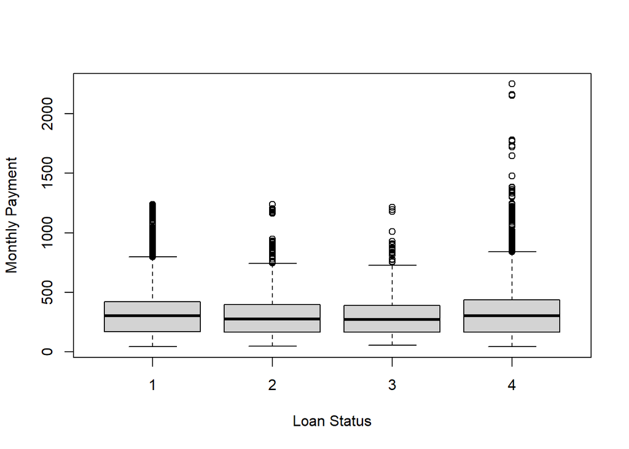

```r
plot(borrowers$loan_status, borrowers$listing_monthly_payment, xlab="Loan Status", ylab="Monthly Payment")
```

> The monthly payment for debtors made no difference in the amount of debtors charging off or defaulting on their loan.

## ScoreX Scores

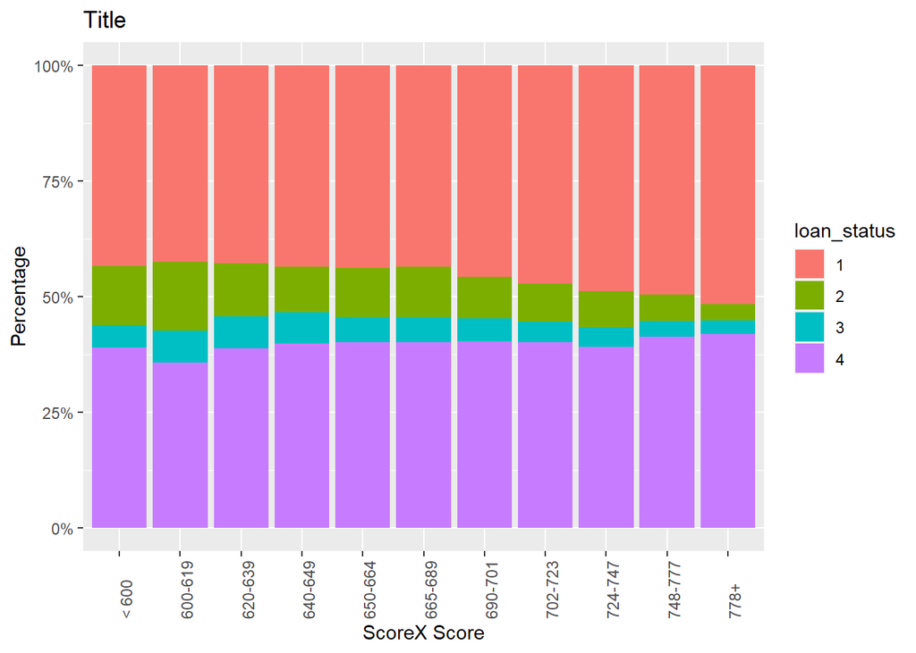

```r
ggplot(borrowers, aes(x=scorex, fill = loan_status)) + geom_bar(stat = "count", position = "fill") + labs(title = "Title") + labs(x="ScoreX Score", y = "Percentage")+ scale_y_continuous(labels = scales::percent) + theme(axis.text.x = element_text(angle = 90,hjust =0 ))
```

> Debtors with a ScoreX Score in the 600 range charged off or defaulted on their loan more often than debtors with a ScoreX Score in the 700 range or above.

## Prosper Score

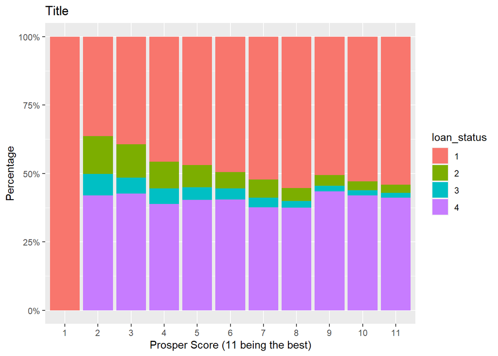

```r
ggplot(borrowers, aes(x=prosper_score, fill = loan_status)) + geom_bar(stat = "count", position = "fill") + labs(title = "Title") + labs(x="Prosper Score (11 being the best)", y = "Percentage")+ scale_y_continuous(labels = scales::percent)
```

> Debtors with lower Prosper scores charged off or defaulted on their loans more often than debtors with higher Prosper scores.

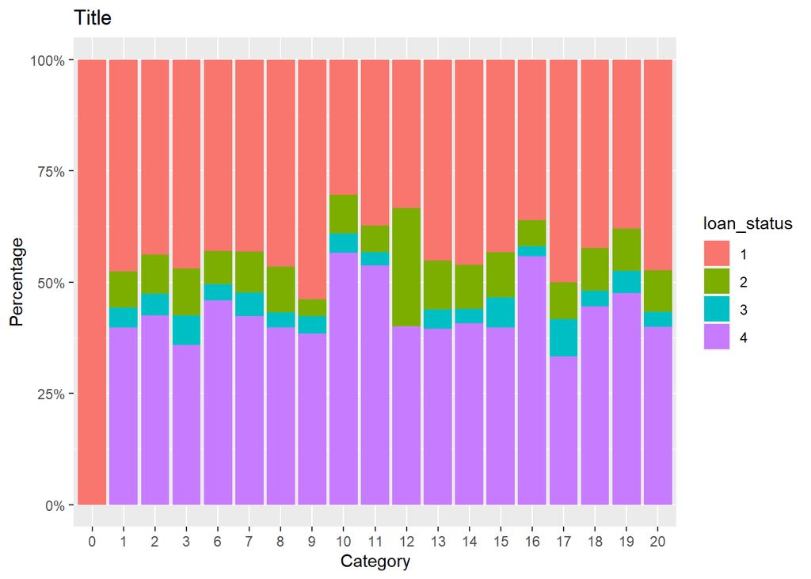

```r
ggplot(borrowers, aes(x=listing_category_id, fill = loan_status)) + geom_bar(stat = "count", position = "fill") + labs(title = "Title") + labs(x="Category", y = "Percentage")+ scale_y_continuous(labels = scales::percent)
```

> Debtors who took out a loan to pay for an RV defaulted on their loan more so than any other category.

## Income Range

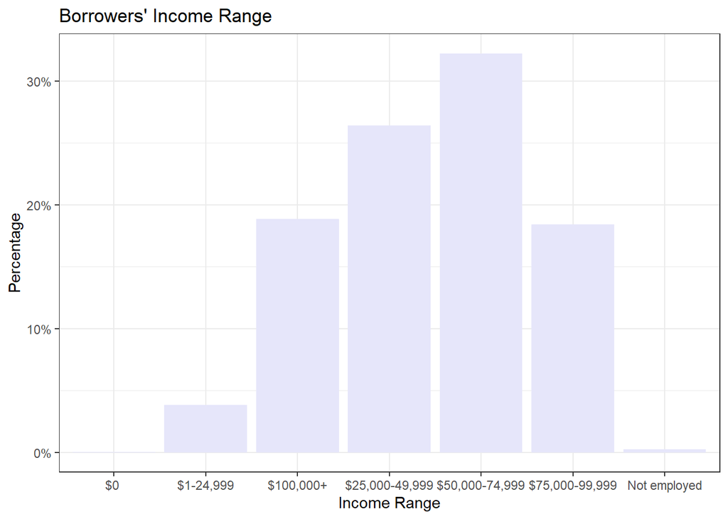

```r
lenders <- subset(lng, lng$lender_indicator == 1)

library(ggplot2)
library(lubridate)

ggplot(borrowers) + geom_bar(aes(x=income_range_description, y=(..count..)/sum(..count..)), fill="lavender") + theme_bw() + xlab("Income Range") + ylab("Percentage") + ggtitle("Borrowers' Income Range") + scale_y_continuous(labels = scales::percent_format(accuracy = 1))
```

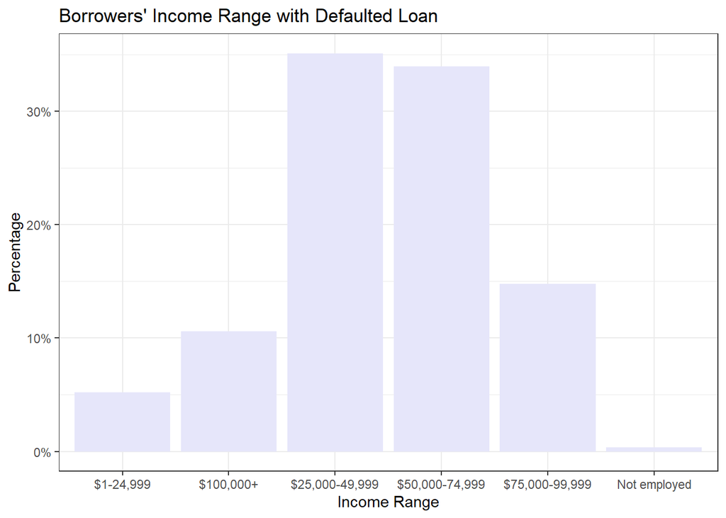

```r
ggplot(data=borrowers[borrowers$loan_status =="3",]) + geom_bar(aes(x=income_range_description, y=(..count..)/sum(..count..)),fill="lavender") + theme_bw() + xlab("Income Range") + ylab("Percentage") + ggtitle("Borrowers' Income Range with Defaulted Loan") + scale_y_continuous(labels = scales::percent)
```

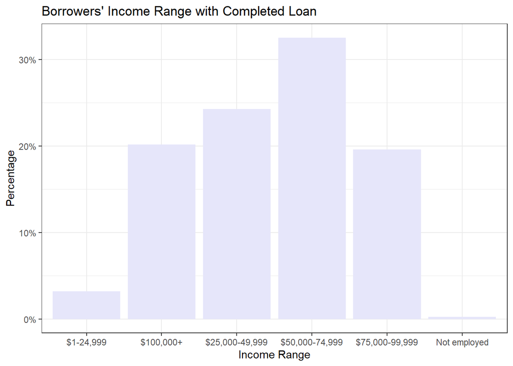

```r
ggplot(data=borrowers[borrowers$loan_status =="4",]) + geom_bar(aes(x=income_range_description, y=(..count..)/sum(..count..)), fill="lavender") + theme_bw() + xlab("Income Range") + ylab("Percentage") + ggtitle("Borrowers' Income Range with Completed Loan") + scale_y_continuous(labels = scales::percent_format(accuracy = 1))
```

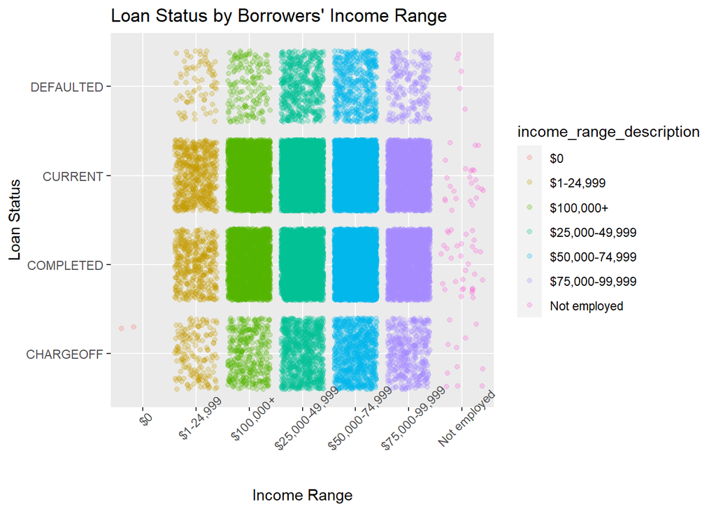

```r
ggplot(data=borrowers[borrowers$income_range_description!="$0",], aes(x=income_range_description, y = loan_status_description, colour=income_range_description)) + geom_jitter(alpha = 0.25) + xlab("Income Range") + ylab("Loan Status") + ggtitle("Loan Status by Borrowers' Income Range") + theme(axis.text.x = element_text(angle = 45))
```

> Generally speaking, borrowers with income more than $25,000 are more likely to complete their loans than those income falling under $25,000.